# 36-315 Lab 07

SOLUTIONS

Due Saturday, October 23, 2021 (12:00pm)

## Lab 07: Pairs Plots, Contour Plots, Heat Maps, Distances

# Problem 1: Pairs Plots (30 points)

If you get stuck on any of these problems, it’ll be helpful to refer back to the Lecture14 R Demo (on Canvas).

Since we’ll be making pairs plots, I really wanted to find a dataset on pears. Because, you know, for the pun. Unfortunately, I couldn’t find one - the closest I could get is a dataset on olive oils:

```r
olive = read.csv("https://raw.githubusercontent.com/zjbranson/315Fall2021/master/olive.csv")
```

This dataset appears on Homework7. This dataset contains two categorical variables (`area` and `region`) and eight quantitative variables. [For more information on the data, see here.](https://raw.githubusercontent.com/zjbranson/315Fall2021/master/olive_description.txt)

**Note: The units for the variables in this dataset are a little confusing, so don’t worry about including units on your graphs for this assignment.**

1. (10pts) For this part, complete these tasks:
- Using either `subset()` or `dplyr::select()`, create a subset of the `olive` dataset that only contains the `area` and `region` variables, as well as three quantitative variables of your choice. Call this subset `olive.subset`.

```r
olive.subset = subset(olive, select = c(palmitic, palmitoleic, stearic, area, region))
```

- Then, create a pairs plot of just the quantitative variables using `ggpairs`. You’ll need to install and load the `GGally` package to do this.

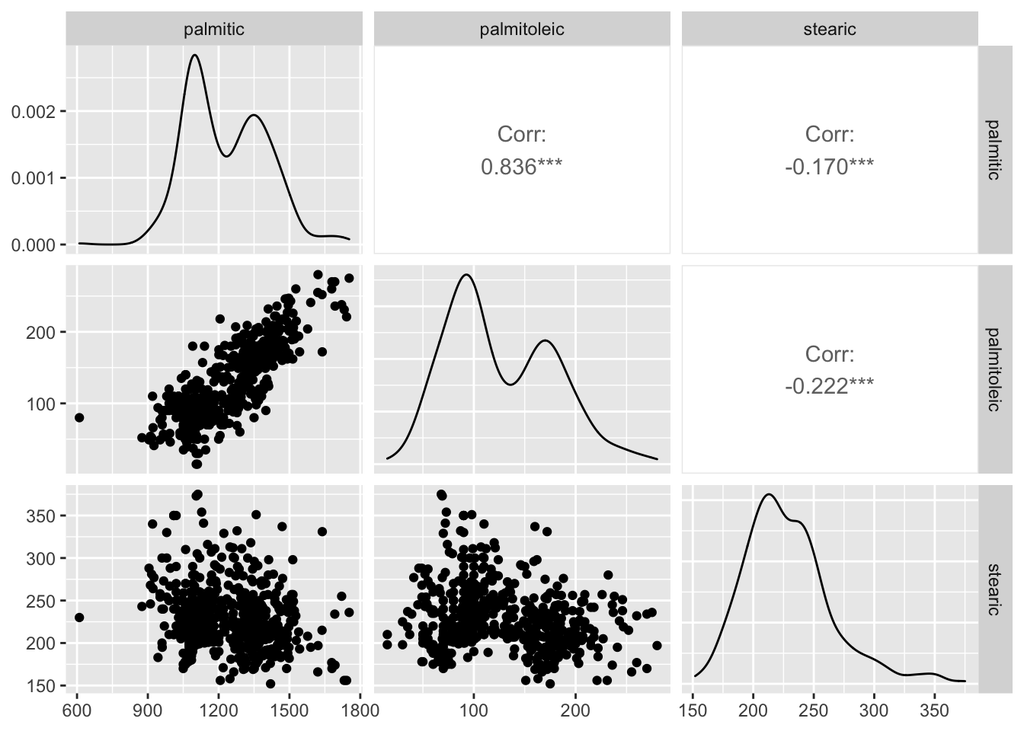

```r
library(GGally)
ggpairs(olive.subset, columns = 1:3)
```

- Answer this question: Which pair of variables has the weakest correlation?

*Here we see that `stearic` and `palmitic` have the weakest correlation (-0.170).*

2. (10pts) Now create a scatterplot of the pair of quantitative variables that has the weakest correlation (which you should have determined in Part A). In your scatterplot, let color depend on `region`, and let shape depend on `area`. Furthermore, set `alpha = 0.7` so that it’s easier to see overlapping points.

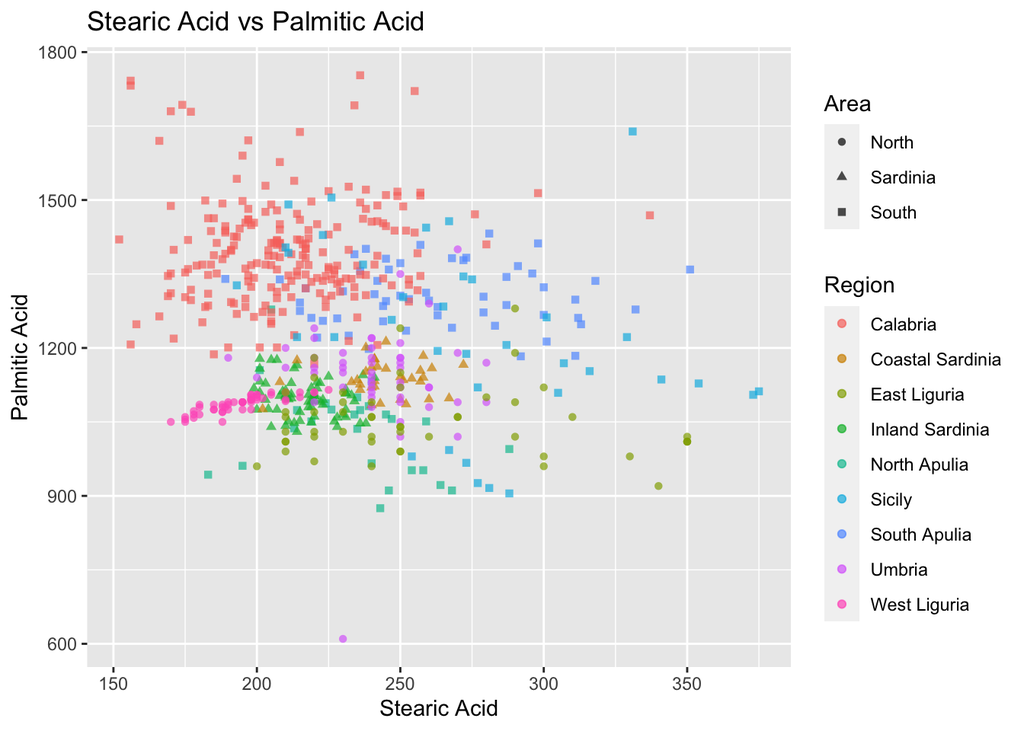

```r
ggplot(olive.subset, aes(x = stearic, y = palmitic,
                      color = region, shape = area)) +
  geom_point(alpha = 0.7) +
  labs(title = "Stearic Acid vs Palmitic Acid",
       x = "Stearic Acid",
       y = "Palmitic Acid",
       color = "Region",
       shape = "Area")
```

**All you need to do for this part is turn in the plot, but ask yourself: How would I use this plot to determine if certain areas or regions appear to be associated or grouped with each other?**

*Using the above plot, we can assess whether certain colors/shapes tend to be clustered together in one part of the graph—this would suggest if certain regions/areas tend to be grouped together. In the above plot, there seems to be distinct clustering by several regions: For example, Calabria is almost exclusively in the upper left of the graph, and West Liguria is tightly clustered in the bottom left. We can also see that Sardinia (which includes Coastal Sardinia and Inland Sardinia) is very tightly clustered in the middle-left of the graph.*

3. (10pts) Now create a pairs plot of (1) the two quantitative variables you visualized in Part B, (2) `area`, and (3) `region`.

*The goal of this part is to make a pairs plot of `stearic`, `palmitic`, `area`, and `region`. Note that these are the first, third, fourth, and fifth columns in `olive.subset`:*

```r
names(olive.subset)
```

```
## [1] "palmitic"    "palmitoleic" "stearic"     "area"        "region"
```

*Thus, here is the desired pairs plot:*

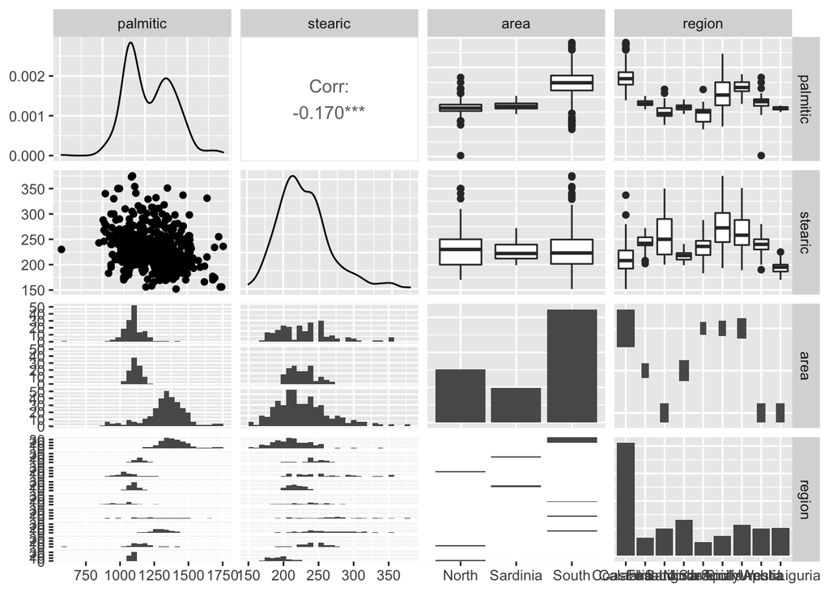

```r
ggpairs(olive.subset, columns = c(1, 3, 4, 5))
```

After you’ve made your plot, answer this question: For each quantitative variable, which plot within the pairs plot would you use to describe the distribution of that variable *conditional on `area`*? You don’t have to describe the distributions, but your answer should mention two plots within the pairs plot (one for each quantitative variable) that would allow you to describe the distributions if you had to.

*To describe the distribution of `stearic` conditional on `area`, I would use the side-by-side boxplot in the second row, third column. To describe the distribution of `palmitic` conditional on `area`, I would use the side-by-side boxplot in the first row, third column.*

*[You could also use the facetted histograms in the third row, but I prefer the side-by-side boxplots because it’s easier to determine which distribution corresponds to which `area`.]*

# Problem 2: Contour Plots and Heat Maps (30 points)

1. (20pts) Recreate your scatterplot from Problem 1B, but now overlay a 2D density estimate of the joint distribution of the two quantitative variables in the form of a contour plot. For this part, be sure to define the `color` and `shape` of the points within `geom_point()`, **NOT** in `ggplot()`.

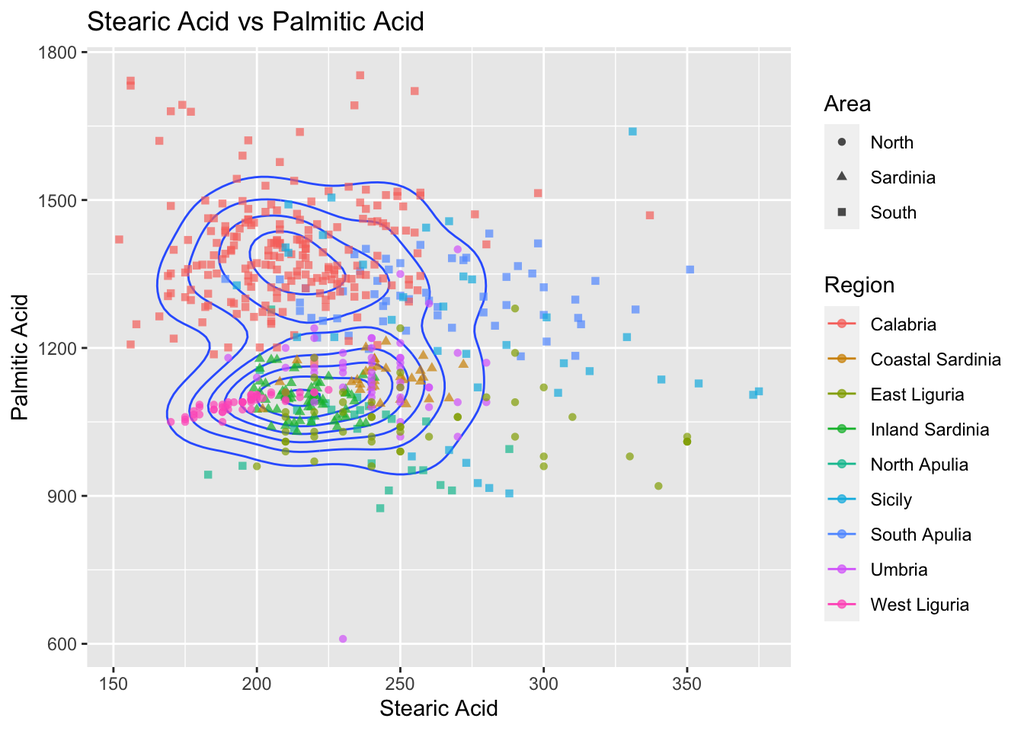

```r
ggplot(olive.subset, aes(x = stearic, y = palmitic)) +
  geom_density2d() +
  geom_point(aes(color = region, shape = area), alpha = 0.7) +
  labs(title = "Stearic Acid vs Palmitic Acid",
       x = "Stearic Acid",
       y = "Palmitic Acid",
       color = "Region",
       shape = "Area")
```

After you’ve made your graph, answer the following questions: Are there any modes/groups apparent in the data? If so, describe each mode/group in terms of the two quantitative variables, as well as `area` and `region`.

*There appear to be two modes in the data: one around 215 Stearic Acid and 1350 Palmitic Acid and the other around 220 Stearic Acid and 1100 Palmitic Acid. The first mode seems to correspond with Calabria from the South area (and to a lesser extent, Sicily and South Apulia). The second seems to correspond with the North and Sardinia areas.*

2. (10pts) Now create a heat map of the two variables you used in your scatterplot. Remove the color and shape of the points, and use a non-default color scheme in your heatmap. To do this, copy-and-paste your code from Part A, and then replace `geom_density2d` with `stat_density2d(aes(fill = ..density..), geom = "tile", contour = F)`, and delete the specifications for `color` and `shape`. When doing this, be sure that `geom_point()` comes *after* `stat_density2d()` (otherwise, the points won’t display). To change the default colors, use `scale_fill_gradient()`. (Again, it may be helpful to look back at the Lecture14 R Demo.)

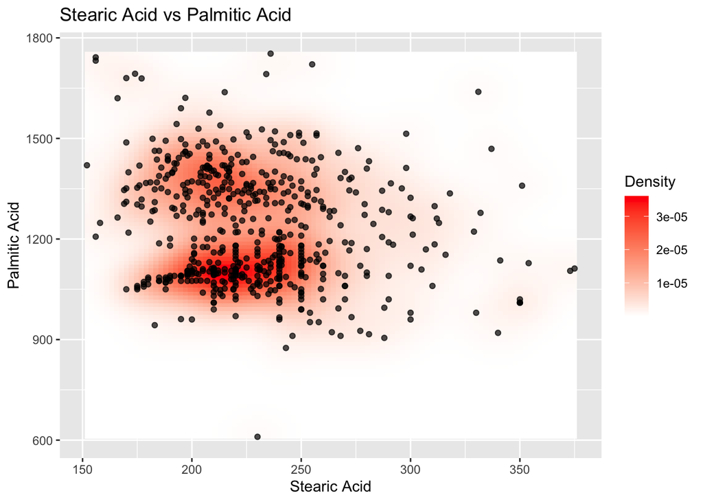

```r
ggplot(olive.subset, aes(x = stearic, y = palmitic)) +
  stat_density2d(aes(fill = ..density..), geom = "tile", contour = F) +
  geom_point(alpha = 0.7) +
  scale_fill_gradient(low = "white", high = "red") +
  labs(title = "Stearic Acid vs Palmitic Acid",
       x = "Stearic Acid",
       y = "Palmitic Acid",
       fill = "Density")
```

# Problem 3: Multi-dimensional Scaling (40 points)

Now we’ll work with the student performance dataset (which was shown in the Lecture15 R Demo) and also appears on Homework7. Here’s the code to read in the data:

```r
data = read.csv("https://raw.githubusercontent.com/zjbranson/315Fall2021/master/students.csv")
```

This problem will teach you how to implement and visualize multi-dimensional scaling (MDS) in `R`, which was demonstrated in the Lecture15 `R` Demo (and thus that may be helpful for this problem).

1. (15pts) First, perform the following steps:
- Create a subset of the student data that only contains the four quantitative variables `RaisedHands`, `VisitedResources`, `AnnouncementsView`, and `Discussion`.

```r
#Just the quantitative variables:
data.subset = subset(data,
    select = c("RaisedHands", "VisitedResources", "AnnouncementsView", "Discussion"))
```

- **Standardize your variables** by dividing each column by its standard deviation (the `R` demo shows you how to do this in one line of code).

```r
#Standardize the data such that each column has variance 1:
data.subset = apply(data.subset, MARGIN = 2, FUN = function(x) x/sd(x))
```

- Create a distance matrix using the Euclidean distance using the `dist()` function.

```r
#distance matrix
data.subset.dist = dist(data.subset)
```

- Implement MDS using the `cmdscale()` function with $k = 2$.

```r
#perform MDS
mds = cmdscale(data.subset.dist, k = 2)
```

- Add the two dimensions from MDS to your dataset. To do this, run the following code:

```r
data$mds1 = mds[,1]
data$mds2 = mds[,2]
```

where `mds` is the MDS object you produced from `cmdscale()`.

After doing all of this, make a scatterplot of the two dimensions from MDS. Your scatterplot should look identical to the scatterplot shown in the Lecture15 `R` demo.

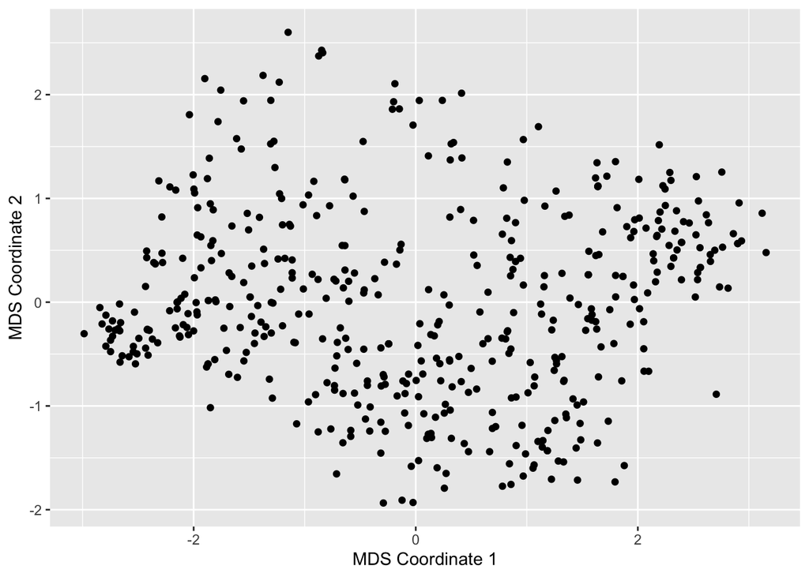

```r
#scatterplot of the two MDS dimensions
ggplot(data, aes(x = mds1, y = mds2)) + geom_point() +
  labs(x = "MDS Coordinate 1", y = "MDS Coordinate 2")
```

2. (10pts) It’s hard to interpret a scatterplot like the one in Part A unless the points clearly cluster amongst themselves, and that doesn’t really seem to be the case here. However, we can use contour lines to identify modes in the distribution of the two MDS dimensions. Use `geom_density2d()` to add contour lines to the scatterplot from Part A (include your new plot here).

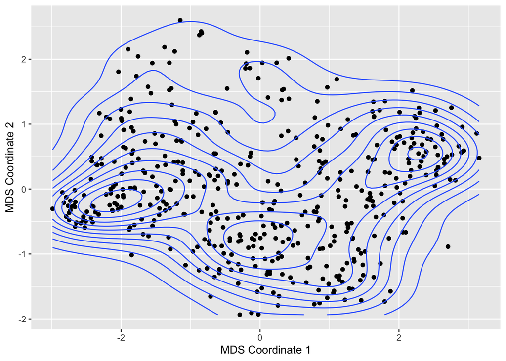

```r
#Same plot, but with contour lines
ggplot(data, aes(x = mds1, y = mds2)) + geom_point() + geom_density2d() +
  labs(x = "MDS Coordinate 1", y = "MDS Coordinate 2")
```

3. (15pts) Now copy-and-paste your code from Part B, and then change your code in the following ways:
- Color the points by their `Grade`.
- Change the point shape according to the `AbsentDays` variable.
- Use the `scale_shape_manual()` function to change the point types so that they are letters corresponding to the number of absent days (A for Above-7 and U for Under-7), i.e. `+ scale_shape_manual(values = c("Above-7" = "A", "Under-7" = "U"))`.
- Adjust the `size` of the points by setting `size = 3` in order to make the graph easier to read.

In your plot, make sure that there is just a single set of contour lines, **NOT** multiple contour lines of different colors.

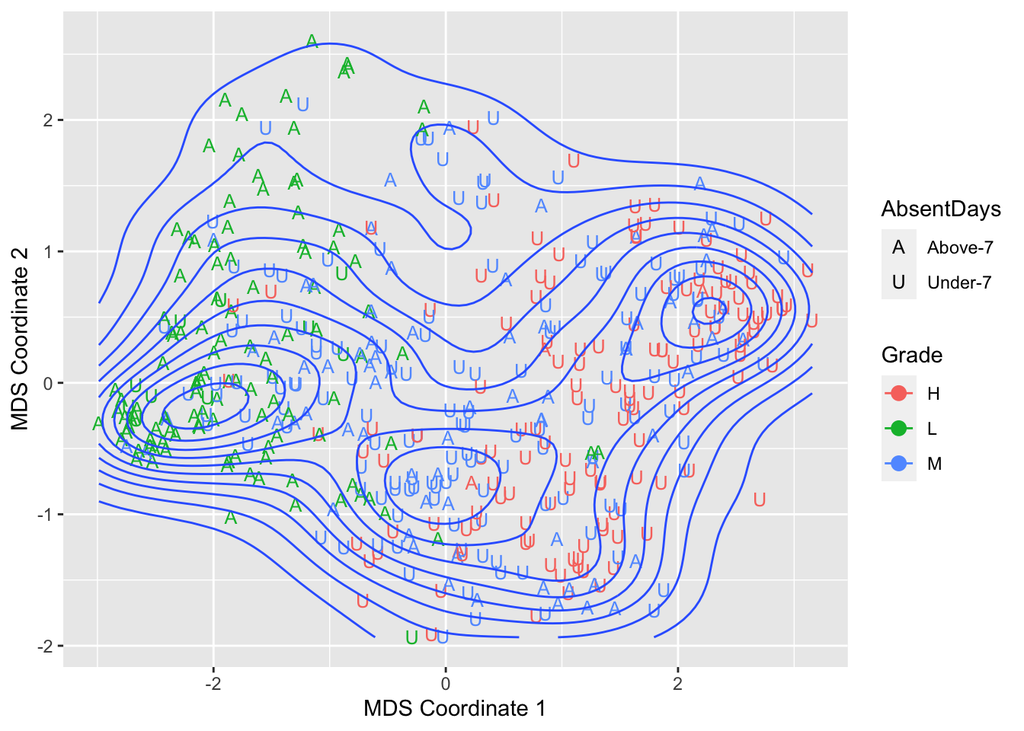

```r
#Same plot, but with color for Grade,
#shape for Absent Days (as text),
#and bigger points.
ggplot(data, aes(x = mds1, y = mds2)) + geom_point(aes(color = Grade, shape = AbsentDays), size = 3) +
geom_density2d() + scale_shape_manual(values = c("Above-7" = "A", "Under-7" = "U")) + labs(x = "MDS Coordinate 1", y = "MDS Coordinate 2")
```

**All you need to do for this part is turn in the plot, but ask yourself: How would I use this plot to determine if the group structure in the student dataset corresponds to the categories of `Grade` and/or `AbsentDays`?**

*Although you didn’t have to interpret the plot, here is some interpretation. We observe some grouping by `Grade`. Students with high grades tend to have the highest first dimension of MDS, followed by students with middle grades, followed by students with low grades. There is also some grouping by `AbsentDays`: The majority of students who were absent more than 7 days have a first MDS dimension below zero. Thus, it appears that students are clustering more by the first MDS dimension than the second.*